# Hurricane Dorain Temporal and Text Analysis

Joseph Holler

First Last

2025-01-09

# Set up environment

Previously installed packages

```r
#install.packages("tidyverse")
#install.packages("here")
```

Install new spatial packages

```r
install.packages("sf")
install.packages("tidycensus")
```

Load packages

Check & create private data folder

```r
if(!dir.exists(here("data_private"))) {dir.create(here("data_private"))}
```

# Set up data

Create a file path for Dorian data

```r
# set file path
dorianFile <- here("data_private", "dorian_raw.RDS")
# show the file path
dorianFile
```

```
## [1] "C:/GitHub/opengisci/wt25_josephholler/data_private/dorian_raw.RDS"
```

Check if Dorian data exists locally. If not, download the data.

```r
if(!file.exists(dorianFile)){
  download.file("https://geography.middlebury.edu/jholler/wt25/dorian/dorian_raw.RDS",
                dorianFile,
                mode="wb")
  }
```

Load Dorian data from RDS file

```r
dorian_raw <- readRDS(dorianFile)
```

# Geographic analysis

Add code to install and load packages for spatial analysis to the beginning of your markdown document, including:

- `sf` for **s**imple (geographic vector) **f**eatures
- `tmap` for thematic mapping
- `tidycensus` for acquiring census data

## Make geographic points for Tweets

First, we need to make geographic points for those Tweets with enough location data to do so. Our end goal will be to map Twitter activity by county, so any source of location data precise enough to pinpoint a user’s county will suffice.

### Location services

The most precise geographic data is the GPS coordinates from a device with location services, stored in the `geo_coords` column, which contains a vector of two decimal numbers.

In data science, `unnest` refers to actions in which when complex content from a single column is parsed out or divided out into numerous columns and/or rows. We can use `unnest_wider` to spread the list content of one column into multiple columns. The challenge is figuring out what the new unique column names will be so that the data frame still functions. In this case, the list items inside `geo_coords` do not have names. We must therefore use the `names_sep` argument to add a separator and suffix number to the resulting columns, producing the names `geo_coords_1` and `geo_coords_2`

```r
dorian_geo <- dorian_raw |>
  unnest_wider(geo_coords, names_sep = "_")
```

We know that most of the `geo_coords` data is `NA` because Twitter users had location services disabled in their privacy settings.

How many Tweets had location services enabled, and thus not `NA` values for geographic coordinates? Answer with the next code block.

```r
dorian_geo |> filter(!is.na(geo_coords_1)) |> count()
```

```
## # A tibble: 1 × 1
##       n
##   <int>
## 1  1274
```

We know that geographic coordinates in North America have negative *x* longitude values (west) and positive *y* latitude values (north) when the coordinates are expressed in decimal degrees. Discern which `geo_coords` column is which by sampling a 5 of them in the code block below. Hint: `select` can select a subset of columns using many helper functions, including `starts_with` to pick out columns that begin with the same prefix.

```r
dorian_geo |>
  filter(!is.na(geo_coords_1)) |>
  select(starts_with("geo")) |>
  sample_n(5)
```

```
## # A tibble: 5 × 2
##   geo_coords_1 geo_coords_2
##          <dbl>        <dbl>
## 1         40.8        -74.0
## 2         34.8        -77.4
## 3         42.1        -72.0
## 4         30.2        -81.6
## 5         35.8        -78.6
```

Replace ??? below with the correct column suffix.

### Place name

Many users also record a place name for their Tweet, which you investigated earlier. Twitter then translated the place name into a bounding box with four coordinate pairs, stored as a list of eight decimal numbers in `bbox_coords`. We will need to find the center of the bounding box by averaging the *x* coordinates and averaging the *y* coordinates.

In the code block below, convert the single `bbox_coords` column into one column for each coordinate.

```r
dorian_geo_place <- dorian_geo |>
  unnest_wider(bbox_coords,
               names_sep = "_")
```

Sample 5 of the resulting `bbox_coords` columns to determine which columns may be averaged to find the center of the bounding box.

```r
dorian_geo_place |>
  filter(!is.na(bbox_coords_1)) |>
  select(starts_with("bbox")) |>
  sample_n(5)
```

```
## # A tibble: 5 × 8
##   bbox_coords_1 bbox_coords_2 bbox_coords_3 bbox_coords_4 bbox_coords_5
##           <dbl>         <dbl>         <dbl>         <dbl>         <dbl>
## 1         -80.0         -79.7         -79.7         -80.0          36.0
## 2         -95.8         -89.1         -89.1         -95.8          36.0
## 3         -81.4         -81.3         -81.3         -81.4          28.6
## 4         -82.6         -82.3         -82.3         -82.6          27.8
## 5         -74.8         -74.7         -74.7         -74.8          40.2
## # ℹ 3 more variables: bbox_coords_6 <dbl>, bbox_coords_7 <dbl>,
## #   bbox_coords_8 <dbl>
```

For only place names at least as precise as counties (poi, city, or neighborhood), calculate the center coordinates in columns named `bbox_meanx` and `bbox_meany`. It will be easier to find averages using simple math than to use `rowwise` and `c_across` for row-wise aggregate functions.

```r
good_places <- c("poi", "city", "neighborhood")
dorian_geo_place <- dorian_geo_place |>
  mutate(bbox_meanx = case_when(place_type %in% good_places ~
                                  (bbox_coords_1 + bbox_coords_2) / 2),
         bbox_meany = case_when(place_type %in% good_places ~
                                  (bbox_coords_6 + bbox_coords_7) / 2)
         )
```

Sample 5 rows of the place type column and columns starting with bbox for tweets with non-NA place types to see whether the code above worked as expected.

```r
dorian_geo_place |>
  filter(!is.na(place_type)) |>
  select(place_type, starts_with("bbox")) |>
  sample_n(5)
```

```
## # A tibble: 5 × 11
##   place_type bbox_coords_1 bbox_coords_2 bbox_coords_3 bbox_coords_4
##   <chr>              <dbl>         <dbl>         <dbl>         <dbl>
## 1 city               -97.7         -97.2         -97.2         -97.7
## 2 city               -83.7         -83.7         -83.7         -83.7
## 3 admin              -83.7         -75.2         -75.2         -83.7
## 4 city               -96.8         -96.6         -96.6         -96.8
## 5 admin              -83.4         -78.5         -78.5         -83.4
## # ℹ 6 more variables: bbox_coords_5 <dbl>, bbox_coords_6 <dbl>,
## #   bbox_coords_7 <dbl>, bbox_coords_8 <dbl>, bbox_meanx <dbl>,
## #   bbox_meany <dbl>
```

To be absolutely sure, find the aggregate mean of bbox_meanx and bbox_meany by place_type

```r
dorian_geo_place |>
  group_by(place_type) |>
  summarize(mean(bbox_meanx), mean(bbox_meany))
```

```
## # A tibble: 6 × 3
##   place_type   `mean(bbox_meanx)` `mean(bbox_meany)`
##   <chr>                     <dbl>              <dbl>
## 1 admin                      NA                 NA
## 2 city                      -80.9               35.7
## 3 country                    NA                 NA
## 4 neighborhood              -81.9               34.4
## 5 poi                       -78.8               34.7
## 6 <NA>                       NA                 NA
```

Finally, create `xlng` (longitude) and `ylat` (latitude) columns and populate them with coordinates, using geographic coordinates first and filling in with place coordinates second. Hint: if none of the cases are `TRUE` in a `case_when` function, then `.default =` can be used at the end to assign a default value.

```r
dorian_geo_place <- dorian_geo_place |>
  mutate(xlng = case_when(!is.na(geo_coords_2) ~ geo_coords_2,
                          .default = bbox_meanx),
         ylat = case_when(!is.na(geo_coords_1) ~ geo_coords_1,
                          .default = bbox_meany)
  )
```

Sample the `xlng` and `ylat` data along side the geographic coordinates and bounding box coordinates to verify. Re-run the code block until you find at least some records with geographic coordinates.

```r
dorian_geo_place |>
  filter(!is.na(xlng)) |>
  select(xlng, ylat, geo_coords_1, geo_coords_2, bbox_meanx, bbox_meany, place_type) |>
  sample_n(5)
```

```
## # A tibble: 5 × 7
##    xlng  ylat geo_coords_1 geo_coords_2 bbox_meanx bbox_meany place_type
##   <dbl> <dbl>        <dbl>        <dbl>      <dbl>      <dbl> <chr>
## 1 -80.1  26.2         NA           NA        -80.1       26.2 city
## 2 -78.1  33.9         NA           NA        -78.1       33.9 city
## 3 -78.5  36.0         NA           NA        -78.5       36.0 city
## 4 -77.0  38.9         38.9        -77.0      -77.0       38.9 city
## 5 -79.9  36.1         NA           NA        -79.9       36.1 city
```

### Geographic point data

The `sf` pacakge allows us to construct geographic data according to open GIS standards, making tidyverse dataframes into geodataframes analagous to geopackages and shapefiles.

Select the status ID, created date-time, x and y coordinate columns. Filter the data for only those Tweets with geographic coordinates. Then, use the `st_as_sf` function to create geographic point data.

A `crs` is a coordinate reference system, and Geographic coordinates are generally stored in the system numbered `4326` (WGS 1984 geographic coordinates).

```r
tweet_points <- dorian_geo_place |>
  select(status_id, created_at, xlng, ylat) |>
  filter(!is.na(xlng)) |>
  st_as_sf(coords = c("xlng", "ylat"), crs = 4326)
```

Graph (map) the tweets!

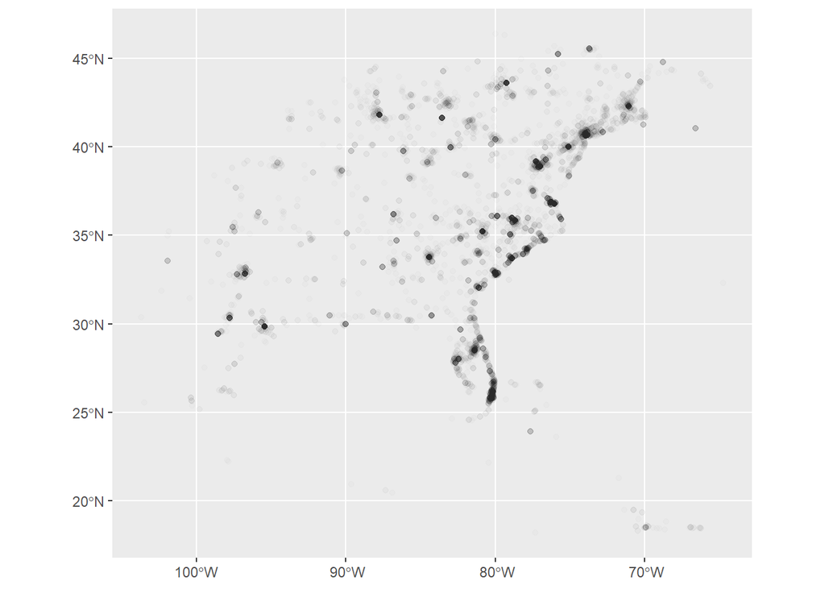

```r
tweet_points |>
  ggplot() +
  geom_sf(alpha=0.01)
```

## Aquire Census data

For details on the variables, see https://api.census.gov/data/2020/dec/dp/groups/DP1.html

### Select counties of interest

select only the states you want, with FIPS state codes look up fips codes here: https://en.wikipedia.org/wiki/Federal_Information_Processing_Standard_state_code

```r
counties <- filter(
  counties,
  STATEFP %in% c(
    "54", "51", "50", "47", "45", "44", "42", "39", "37", "36", "05", "01",
    "34", "33", "29", "28", "25", "24", "23", "22", "21", "18", "17", "13",
    "12", "11", "10", "09"
  )
)

# saveRDS(counties, here("data_public", "counties_east.RDS"))
```

## Map Population Density and Tweet Points

Calculate population density in terms of people per square kilometer of land. `DP1_0001C` is the total population `ALAND` is the area of land in square meters

```r
counties <- mutate(counties,
                   popdensity = DP1_0001C / (ALAND / 1000000))
```

Map population density

We can use `ggplot`, but rather than the `geom_` functions we have seen before for the data geometry, use `geom_sf` for our simple features geographic data.

`cut_interval` is an equal interval classifier, while `cut_number` is a quantile / equal count classifier function. Try switching between the two and regraphing the map below.

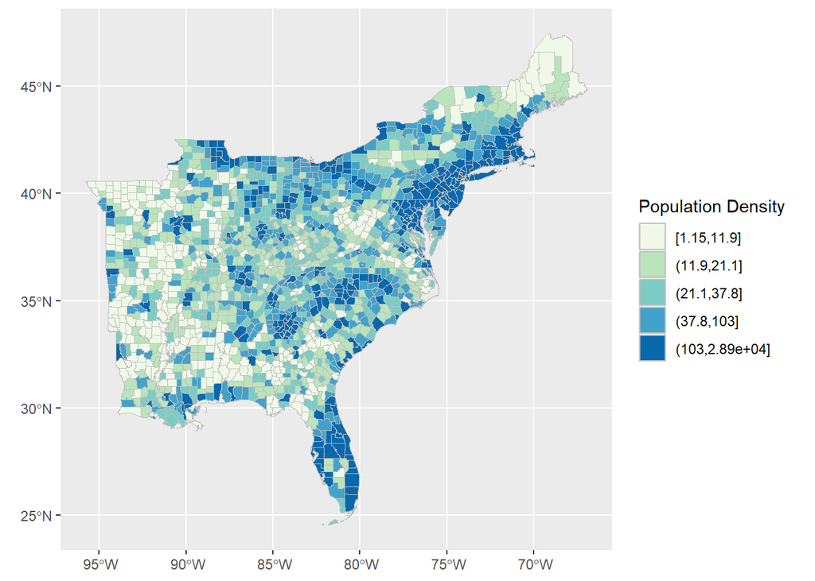

```r
ggplot() +
  geom_sf(data = counties,
    aes(fill = cut_number(popdensity, 5)), color = "grey") +
  scale_fill_brewer(palette = "GnBu") +
  guides(fill = guide_legend(title = "Population Density"))
```

Add twitter points to the map as a second `geom_sf` data layer.

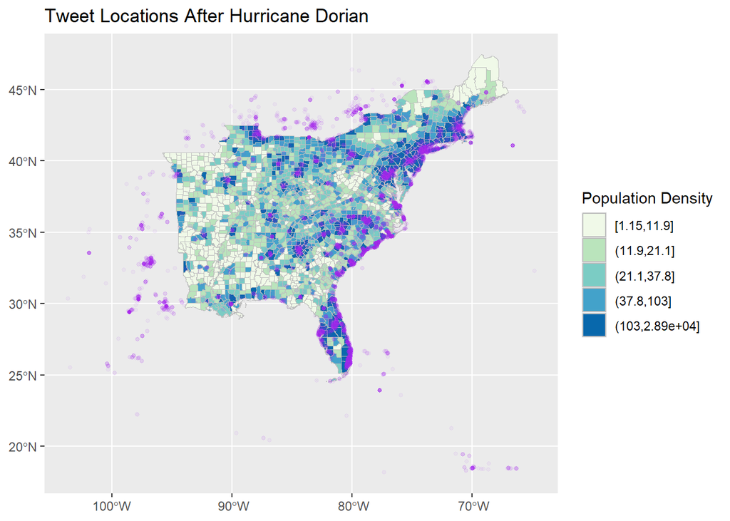

```r
ggplot() +
  geom_sf(data = counties,
    aes(fill = cut_number(popdensity, 5)), color = "grey") +
  scale_fill_brewer(palette = "GnBu") +
  guides(fill = guide_legend(title = "Population Density")) +
  geom_sf(data = tweet_points,
    colour = "purple", alpha = 0.05, size = 1
  ) +
  labs(title = "Tweet Locations After Hurricane Dorian")
```

## Join Tweets to Counties

Transform Tweet points into the North American coordinate system and then check their CRS.

```r
tweet_points <- st_transform(tweet_points, 4269)
st_crs(tweet_points)
```

```
## Coordinate Reference System:
##   User input: EPSG:4269
##   wkt:
## GEOGCRS["NAD83",
##     DATUM["North American Datum 1983",
##         ELLIPSOID["GRS 1980",6378137,298.257222101,
##             LENGTHUNIT["metre",1]]],
##     PRIMEM["Greenwich",0,
##         ANGLEUNIT["degree",0.0174532925199433]],
##     CS[ellipsoidal,2],
##         AXIS["geodetic latitude (Lat)",north,
##             ORDER[1],
##             ANGLEUNIT["degree",0.0174532925199433]],
##         AXIS["geodetic longitude (Lon)",east,
##             ORDER[2],
##             ANGLEUNIT["degree",0.0174532925199433]],
##     USAGE[
##         SCOPE["Geodesy."],
##         AREA["North America - onshore and offshore: Canada - Alberta; British Columbia; Manitoba; New Brunswick; Newfoundland and Labrador; Northwest Territories; Nova Scotia; Nunavut; Ontario; Prince Edward Island; Quebec; Saskatchewan; Yukon. Puerto Rico. United States (USA) - Alabama; Alaska; …
##         BBOX[14.92,167.65,86.45,-40.73]],
##     ID["EPSG",4269]]
```

- Here, we want to map the number, density, or ratio of tweets by county.
- Later on, we may want to filter tweets by their location, or which county and state they are in.
- For both goals, the first step is to join information about counties to individual tweets.
- You’ve already seen data joined by column attributes (GDP per capita and life expectancy by country and year) using `left_join`. Data can also be joined by geographic location with a spatial version, `st_join`. If you look up the default parameters of `st_join`, it will be a **left** join with the join criteria **st_intersects**.

But first, which columns from `counties` should we join to `tweet_points`, if we ultimately want to re-attach tweet data to counties and we might want to filter tweets by state or by state and by county? Hint for those unfamiliar with Census data, the Census uses `GEOID`s to uniquely identify geographic features, including counties. County names are not unique: some states have counties of the same name.

Select the GEOID and useful county and state names from counties, and join this information to tweet points by geographic location. In the `select` below, `=` is used to rename columns as they are selected.

Display a sample of the results and save these useful results as an RDS file.

```r
counties_select_columns <- counties |>
  select(GEOID, county = NAME.x, state = STATE_NAME)

tweet_points <- tweet_points |> st_join(counties_select_columns)

tweet_points |> sample_n(5)
```

```
## Simple feature collection with 5 features and 5 fields
## Geometry type: POINT
## Dimension:     XY
## Bounding box:  xmin: -80.30706 ymin: 25.97612 xmax: -66.588 ymax: 41.07
## Geodetic CRS:  NAD83
## # A tibble: 5 × 6
##   status_id     created_at                      geometry GEOID county      state
## * <chr>         <dttm>                       <POINT [°]> <chr> <chr>       <chr>
## 1 117028113227… 2019-09-07 10:22:19      (-66.588 41.07) <NA>  <NA>        <NA>
## 2 116995969529… 2019-09-06 13:05:02 (-76.06995 36.80254) 51810 Virginia B… Virg…
## 3 116942389900… 2019-09-05 01:35:59 (-80.00737 32.77007) 45019 Charleston  Sout…
## 4 117008353780… 2019-09-06 21:17:09 (-74.16508 40.99852) 34003 Bergen      New …
## 5 116944976066… 2019-09-05 03:18:44 (-80.30706 25.97612) 12011 Broward     Flor…
```

```r
saveRDS(tweet_points, here("data_public", "tweet_locations.RDS"))
```

Pro Tips:

- If you join data more than once (e.g. by re-running the same code block), R will create duplicate field names and start adding suffixes to them (e.g. `.x`, `.y`). If this happens to you, go back and recreate the data frame and then join *only once*.
- Once a data frame is geographic, the geometry column is *sticky*: it stays with the data even if it is not explicitly selected. The only way to be rid of it is with a special `st_drop_geometry()` function. Fun fact: you cannot join two data frames by attribute (e.g. through `left_join()`) if they *both* have geometries.

Now, count the number of tweets per county and *remove the geometry column* as you do so.

```r
tweet_counts <- tweet_points |>
  st_drop_geometry() |>
  count(GEOID)

tweet_counts
```

```
## # A tibble: 602 × 2
##    GEOID     n
##    <chr> <int>
##  1 01001     1
##  2 01003     5
##  3 01007     2
##  4 01015     6
##  5 01017     1
##  6 01021     1
##  7 01043     1
##  8 01045     1
##  9 01047     1
## 10 01051     3
## # ℹ 592 more rows
```

Join the count of tweets to counties and save counties with this data.

```r
counties_tweet_counts <- counties |>
  left_join(tweet_counts, by = "GEOID")

counties_tweet_counts |>
  select(-starts_with(c("DP1", "A")), -ends_with("FP")) |>
  sample_n(5)
```

```
## Simple feature collection with 5 features and 10 fields
## Geometry type: MULTIPOLYGON
## Dimension:     XY
## Bounding box:  xmin: -90.32052 ymin: 33.29781 xmax: -77.47428 ymax: 38.77437
## Geodetic CRS:  NAD83
## # A tibble: 5 × 11
##   COUNTYNS GEOID NAME.x    NAMELSAD       STUSPS STATE_NAME     LSAD  NAME.y
## * <chr>    <chr> <chr>     <chr>          <chr>  <chr>          <chr> <chr>
## 1 01008557 37079 Greene    Greene County  NC     North Carolina 06    Greene Co…
## 2 01671894 13151 Henry     Henry County   GA     Georgia        06    Henry Cou…
## 3 00767557 29510 St. Louis St. Louis city MO     Missouri       25    St. Louis…
## 4 00161589 01127 Walker    Walker County  AL     Alabama        06    Walker Co…
## 5 00516915 21137 Lincoln   Lincoln County KY     Kentucky       06    Lincoln C…
## # ℹ 3 more variables: geometry <MULTIPOLYGON [°]>, popdensity <dbl>, n <int>
```

```r
counties_tweet_counts <- counties_tweet_counts |>
  mutate(
    n = replace_na(n, 0),
    tweet_rate = n / DP1_0001C * 10000
    )

counties_tweet_counts |>
  select(-starts_with(c("DP1", "A")), -ends_with("FP")) |>
  sample_n(5)
```

```
## Simple feature collection with 5 features and 11 fields
## Geometry type: MULTIPOLYGON
## Dimension:     XY
## Bounding box:  xmin: -91.26429 ymin: 30.08172 xmax: -79.09581 ymax: 39.22727
## Geodetic CRS:  NAD83
## # A tibble: 5 × 12
##   COUNTYNS GEOID NAME.x    NAMELSAD         STUSPS STATE_NAME     LSAD  NAME.y
## * <chr>    <chr> <chr>     <chr>            <chr>  <chr>          <chr> <chr>
## 1 00516951 21209 Scott     Scott County     KY     Kentucky       06    Scott C…
## 2 00295733 12065 Jefferson Jefferson County FL     Florida        06    Jeffers…
## 3 00695742 28035 Forrest   Forrest County   MS     Mississippi    06    Forrest…
## 4 00758511 29113 Lincoln   Lincoln County   MO     Missouri       06    Lincoln…
## 5 01008573 37125 Moore     Moore County     NC     North Carolina 06    Moore C…
## # ℹ 4 more variables: geometry <MULTIPOLYGON [°]>, popdensity <dbl>, n <int>,
## #   tweet_rate <dbl>
```

Show a table of the county name and tweet rate for the 10 counties with the highest rates

```r
counties_tweet_counts |>
  arrange(desc(tweet_rate)) |>
  select(NAME.y, tweet_rate) |>
  st_drop_geometry() |>
  head(10)
```

```
## # A tibble: 10 × 2
##    NAME.y                             tweet_rate
##    <chr>                                   <dbl>
##  1 Dare County, North Carolina             12.7
##  2 Carteret County, North Carolina         11.2
##  3 Nantucket County, Massachusetts         11.2
##  4 Hyde County, North Carolina              8.72
##  5 Georgetown County, South Carolina        7.26
##  6 Charleston County, South Carolina        6.52
##  7 Horry County, South Carolina             5.95
##  8 Brunswick County, North Carolina         5.93
##  9 New Hanover County, North Carolina       5.58
## 10 Worcester County, Maryland               5.53
```

Should we multiply the tweet rate by a constant, so that it can be interpreted as, e.g. tweets per 100 people? What constant makes the best sense? Adjust and re-run the rate calculation code block above and note the rate you have chosen.

Save the counties data with Twitter counts and rates

```r
saveRDS(counties_tweet_counts, here("data_public", "counties_tweet_counts.RDS"))
```

Make a choropleth map of the tweet rates!

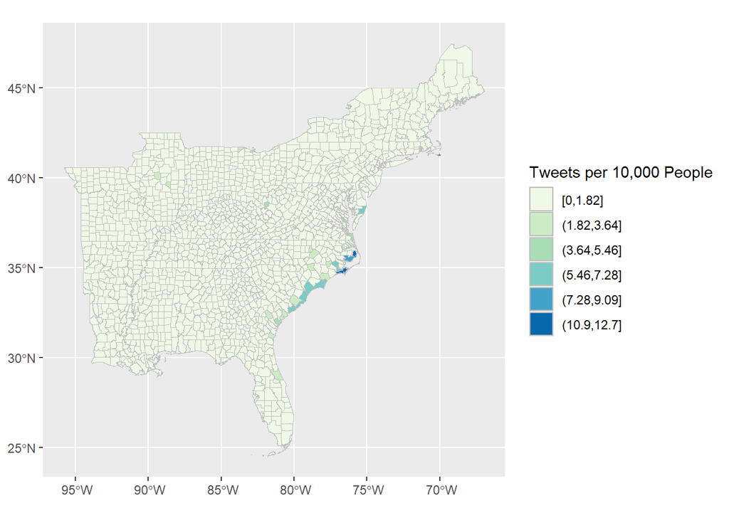

```r
ggplot() +
  geom_sf(data = counties_tweet_counts,
    aes(fill = cut_interval(tweet_rate, 7)), color = "grey") +
  scale_fill_brewer(palette = "GnBu") +
  guides(fill = guide_legend(title = "Tweets per 10,000 People"))
```

# Conclusions

Many things here could still be improved upon! We could…

- Use regular expressions to filter URLs, user handles, and other weird content out of Tweet Content.
- Combine state names into single words for analysis, e.g. NewYork, NorthCarolina using `str_replace`
- Calculate sentiment of each tweet
- Draw word clouds in place of bar charts of the top most frequent words
- Geocode profile location descriptions in order to map more content
- Animate our map of tweets or our graphs of word frequencies by time
- Switch from using `ggplot` for cartography to using `tmap`

For the *second assignment*, by afternoon class on *Tuesday*:

- Complete and knit this Rmd
- To the conclusions, add two or three ideas about *improvements* or elements of *interactivity* that we could add to this analysis.
- Research and try to implement any one of the improvements suggested. This part will be evaluated more based on effort than on degree of success: try something out for 1-2 hours and document the resources you used and what you learned, whether it ultimately worked or not.